# A quick guide to ggfocus

Victor Freguglia

09/08/2018

# Introduction

`ggfocus` is a `ggplot2` extension that allows you to eaily create scales that focus on specific factor levels. This can be achieved in two ways: - Using the `ggfocus()` function with an existing `ggplot` object; or - Adding the scales for the `aes` (`color`, `fill`, `alpha`) you want to use in order to highlight those levels.

When doing data visualization, we often use colors as a third dimension for categorical variables. This package is specially useful for data with too many levels of a categorical variable where only a few of those levels is of interest, mainly because we cannot fully process the information from plots with more than maybe 6 or 8 colors.

In this type of situation, one needs to create new column(s) to select which categories to focus on. The goal of `ggfocus` is to make this step automatical, saving the user’s time.

# Usage

As mentioned in the previous section, you can either use `ggfocus()` to automatically highlight categories in an existing `ggplot` object, or adding the focusing scales with `scale_*_focus()` functions. The important thing to understand is:

- `ggfocus()` uses pipes (`%>%`) and returns a modified version of the `ggplot` object.
- `scale_*_focus()` uses the usual grammar from `ggplot2` (`+`) and behaves exactly like most other scale creation functions.

(Please note that `ggfocus` refers to the package and `ggfocus()` refers to the function in the package)

# Examples

Let’s use the `gapminder` dataset to create examples of how each approach can be used:

- First, we create a `ggplot` that shows the `lifeExp` curve over time for each country and color those with the `continent` factor variable.

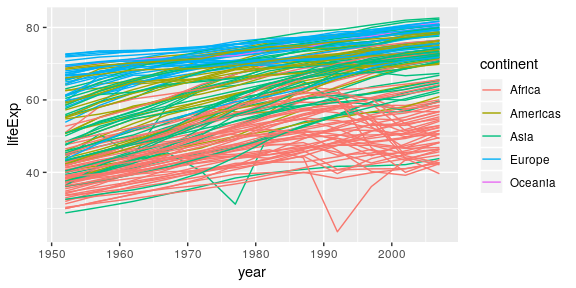

```r
library(ggplot2)
library(ggfocus)
library(gapminder)

p1 <- ggplot(gapminder, aes(x = year, y = lifeExp, color = continent, group = country)) + geom_line()
p1
```

- We can first focus `Europe` continent with `ggfocus()`. This allows us to focus our visualization in European contries without losing the information of what happens in the other countries. I recommend reading the function documentation for information about the parameters.

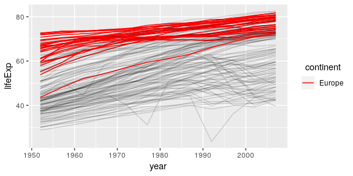

```r
p1 %>% ggfocus(var = continent, focus_levels = c("Europe"), focus_aes = c("color","alpha"),
          color_focus = "red", alpha_focus = 1, alpha_other = 0.15)
```

- The same can be done with `scale` functions

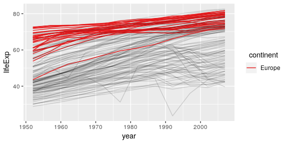

```r
#p1 + scale_alpha_focus(focus_levels = "Europe") # This throws an error because alpha isn't mapped by any variable.
p1 + aes(alpha = continent) + scale_alpha_focus("Europe", 1, 0.15) + scale_color_focus("Europe")
```

- You can highlight multiple levels too!

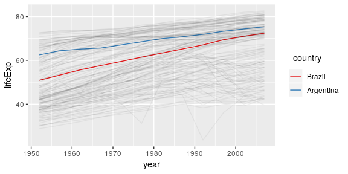

```r
p2 <- ggplot(gapminder, aes(x = year, y = lifeExp, color = country, group = country)) + geom_line()
p2 + scale_color_focus(focus_levels = c("Brazil","Argentina")) + aes(alpha = country) +
  scale_alpha_focus(c("Brazil","Argentina"))
```

```r
# Same as
# p2 %>% ggfocus(var = country, focus_levels = c("Brazil","Argentina"))
```

- `fill` aesthetics is also available

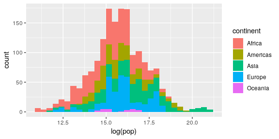

```r
p3 <- ggplot(gapminder, aes(x = log(pop), fill = continent)) + geom_histogram()
p3
## `stat_bin()` using `bins = 30`. Pick better value with `binwidth`.
```

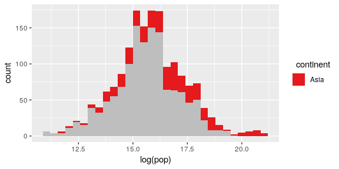

```r
p3 + scale_fill_focus(c("Asia"))
## `stat_bin()` using `bins = 30`. Pick better value with `binwidth`.
```

```r
# Same as
# p3 %>% ggfocus(var = continent, focus_levels = "Asia", focus_aes = "fill", color_other = "gray")
```

- Other cool examples including maps and animations can be found in the package README.

# Additional Comments

- There is another package with similar functionalities called gghighlight. I recommend checking it out because `gghighlight` might be more suitable for some problems.
- I also recommend reading the package’s [README](https://github.com/Freguglia/ggfocus) for extra usage and bug report information.